# Resource Quality Experiment Analysis

```r
Anova(mhemocytemod2)
```

```
## Note: model has aliased coefficients
##       sums of squares computed by model comparison
```

```
## Anova Table (Type II tests)
##
## Response: HemocytesPerSpore
##                       Sum Sq Df F value  Pr(>F)
## Diet                   6.965  3  0.3007 0.82449
## Clone                 23.987  1  3.1068 0.09324 .
## length.um              7.868  1  1.0190 0.32481
## Diet:Clone             3.690  2  0.2389 0.78968
## Diet:length.um        27.163  3  1.1727 0.34499
## Clone:length.um        1.592  1  0.2062 0.65461
## Diet:Clone:length.um  10.573  2  0.6847 0.51567
## Residuals            154.415 20
## ---
## Signif. codes:  0 '***' 0.001 '**' 0.01 '*' 0.05 '.' 0.1 ' ' 1
```

```r
AIC(mhemocytemod2)
```

```
## [1] 177.9395
```

```r
# Hemocytes per spore and NOT including body size as a predictor
mhemocytemod3 <- lm(HemocytesPerSpore ~ Diet * Clone, data = m_data_hemocytes)
# Note: left off the block random effect because all these animals were in the same block
summary(mhemocytemod3)
```

```
##
## Call:
## lm(formula = HemocytesPerSpore ~ Diet * Clone, data = m_data_hemocytes)
##
## Residuals:
##     Min      1Q  Median      3Q     Max
## -4.1050 -1.4429 -0.4982  1.3275  6.5617
##
## Coefficients: (1 not defined because of singularities)
##                      Estimate Std. Error t value Pr(>|t|)
## (Intercept)            4.1050     0.8660   4.740 6.12e-05 ***
## DietSM                -1.4213     1.6201  -0.877   0.3881
## DietM                 -3.6050     2.1212  -1.699   0.1007
## DietM+                -0.4383     1.8027  -0.243   0.8097
## CloneStandard         -1.8087     1.2247  -1.477   0.1513
## DietSM:CloneStandard       NA         NA      NA       NA
## DietM:CloneStandard    4.9753     2.7838   1.787   0.0851 .
## DietM+:CloneStandard  -0.3580     2.7838  -0.129   0.8986
## ---
## Signif. codes:  0 '***' 0.001 '**' 0.01 '*' 0.05 '.' 0.1 ' ' 1
##
## Residual standard error: 2.739 on 27 degrees of freedom
## Multiple R-squared:  0.2067, Adjusted R-squared:  0.03046
## F-statistic: 1.173 on 6 and 27 DF,  p-value: 0.3498
```

```r
Anova(mhemocytemod3)
```

```
## Note: model has aliased coefficients
##       sums of squares computed by model comparison
```

```
## Anova Table (Type II tests)
##
## Response: HemocytesPerSpore
##             Sum Sq Df F value Pr(>F)
## Diet        10.468  3  0.4653 0.7089
## Clone        8.313  1  1.1085 0.3017
## Diet:Clone  25.710  2  1.7141 0.1991
## Residuals  202.487 27
```

```r
AIC(mhemocytemod3) # AIC is lower without bodyzie
```

```
## [1] 173.1545
```

```r
mhemocytemod_contrasts <- emmeans(mhemocytemod3, specs = pairwise ~ Diet | Clone, type = "response")
mhemocytemod_contrasts
```

```
## $emmeans
## Clone = Mid37:
##  Diet emmean    SE df lower.CL upper.CL
##  S     4.105 0.866 27    2.328     5.88
##  SM   nonEst    NA NA       NA       NA
##  M     0.500 1.936 27   -3.473     4.47
##  M+    3.667 1.581 27    0.423     6.91
##
## Clone = Standard:
##  Diet emmean    SE df lower.CL upper.CL
##  S     2.296 0.866 27    0.519     4.07
##  SM    0.875 1.369 27   -1.934     3.68
##  M     3.667 1.581 27    0.423     6.91
##  M+    1.500 1.936 27   -2.473     5.47
##
## Confidence level used: 0.95
##
## $contrasts
## Clone = Mid37:
##  contrast  estimate   SE df t.ratio p.value
##  S - SM      nonEst   NA NA      NA      NA
##  S - M        3.605 2.12 27   1.699  0.3435
##  S - (M+)     0.438 1.80 27   0.243  0.9948
##  SM - M      nonEst   NA NA      NA      NA
##  SM - (M+)   nonEst   NA NA      NA      NA
##  M - (M+)    -3.167 2.50 27  -1.267  0.5912
##
## Clone = Standard:
##  contrast  estimate   SE df t.ratio p.value
##  S - SM       1.421 1.62 27   0.877  0.8165
##  S - M       -1.370 1.80 27  -0.760  0.8715
##  S - (M+)     0.796 2.12 27   0.375  0.9816
##  SM - M      -2.792 2.09 27  -1.335  0.5497
##  SM - (M+)   -0.625 2.37 27  -0.264  0.9934
##  M - (M+)     2.167 2.50 27   0.867  0.8218
##
## P value adjustment: tukey method for comparing a family of 4 estimates
```

```r
# Marginal effects
metsch_hemocytes <- ggpredict(mhemocytemod, c("TotalPunctSpores", "Diet", "Clone"))
```

```
## Could not compute variance-covariance matrix of predictions. No confidence intervals are returned.
```

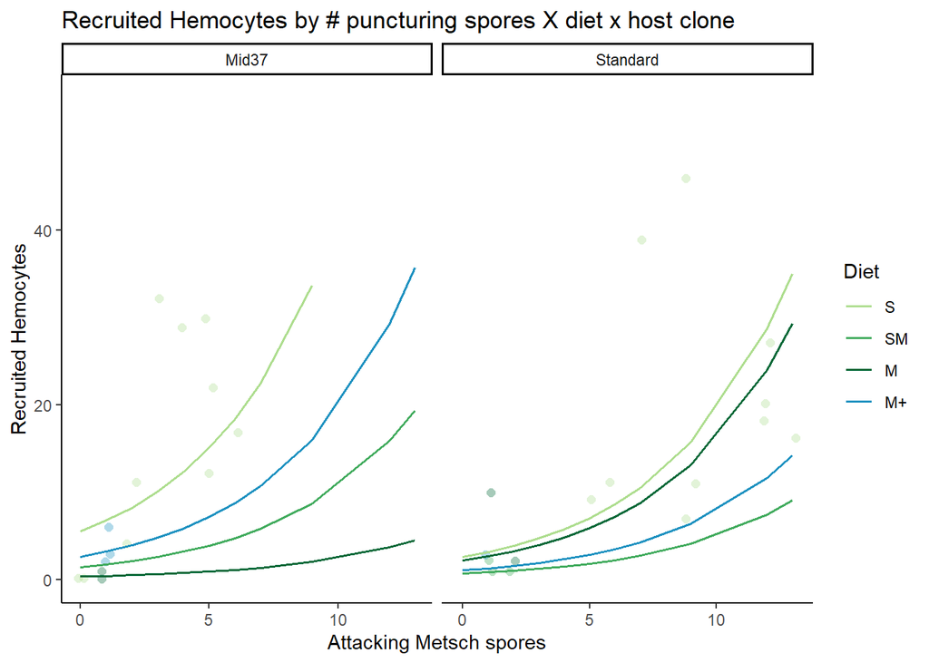

```r
# figure with Total punctured spores
m_hemocytes_fig <- plot(metsch_hemocytes, dodge = 0.4, add.data = T) +
  scale_color_manual(values = diet_colors) +
  scale_fill_manual(values = diet_colors) +
  ggtitle("Recruited Hemocytes by # puncturing spores X diet x host clone") +
  labs(x = "Attacking Metsch spores", y = "Recruited Hemocytes") +
  ylim(0,55) +
  theme_classic()
m_hemocytes_fig
```

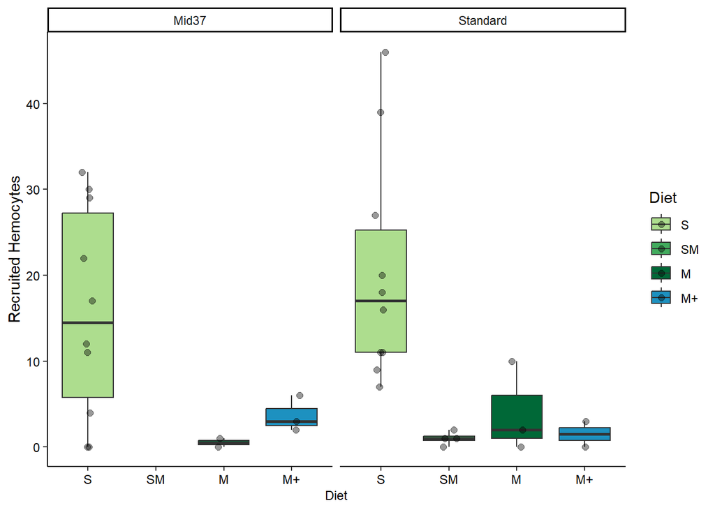

```r
## Figure for presentation
m_hemocytes_fig2 <- ggplot(m_data_hemocytes, aes(x = Diet, y = Hemocytes)) +
  geom_boxplot(aes(fill=Diet),position=position_dodge(width=0.7)) +
  geom_point(aes(color=Diet), size=2, position=position_jitterdodge(dodge.width=0.7, jitter.width = 0.7), alpha = 0.4) +
  facet_wrap(~Clone) +
  scale_fill_discrete(limits = c("S", "SM", "M", "M+")) +
  scale_shape_discrete(limits = c("S", "SM", "M", "M+")) +
  scale_fill_manual(values = diet_colors) +
  scale_color_manual(values = c(rep("black", 4))) +
  #ggtitle("Hemocytes per attacking Metsch spore in the gut by diet x host clone") +
  labs(x = "Diet", y = "Recruited Hemocytes") +
  theme_classic() +
  theme(axis.text = element_text(size=9, color = "black"), axis.title.y = element_text(size=11, color="black"),
        axis.title.x = element_text(size=9, color="black"))
m_hemocytes_fig2
```

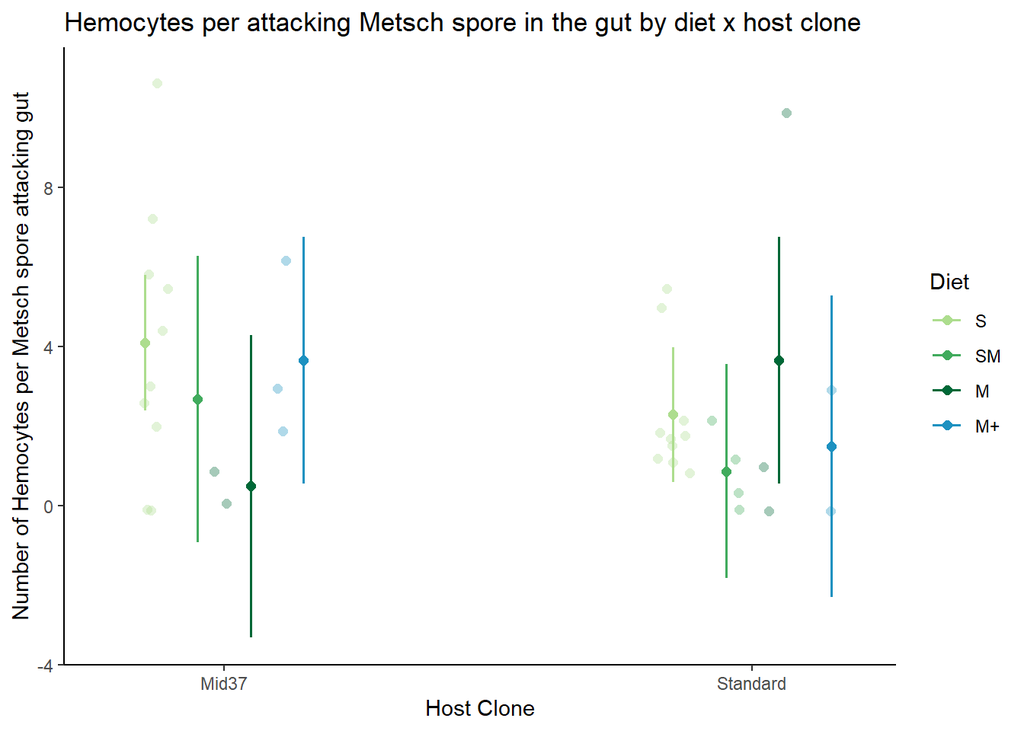

```r
ggsave("figures/Hemocytes_DietxClone.tiff", plot = m_hemocytes_fig2, dpi = 600, width = 5, height = 4, units = "in", compression="lzw")




# Marginal effects from best model with Abundance on the x axis
# metsch_hemocytes <- ggpredict(mhemocytemod, c("length.um", "Diet", "Clone"))
#
# # figure with bodysize
# m_hemocytes_fig2 <- plot(metsch_hemocytes, dodge = 0.4, add.data = T) +
#   scale_color_manual(values = diet_colors) +
#   scale_fill_manual(values = diet_colors) +
#   ggtitle("Recruited Hemocytes by bodysize X diet x host clone") +
#   labs(x = "Length (um)", y = "Recruited Hemocytes") +
#   ylim(0,55) +
#   theme_classic()
# m_hemocytes_fig2



# Marginal effects
metsch_hemocytesperspore <- ggpredict(mhemocytemod3, c("Clone", "Diet"))
# figure with bodysize
m_hemocytesperspore_fig <- plot(metsch_hemocytesperspore, dodge = 0.4, add.data = T) +
  scale_color_manual(values = diet_colors) +
  ggtitle("Hemocytes per attacking Metsch spore in the gut by diet x host clone") +
  labs(x = "Host Clone", y = "Number of Hemocytes per Metsch spore attacking gut") +
  theme_classic()
m_hemocytesperspore_fig
```

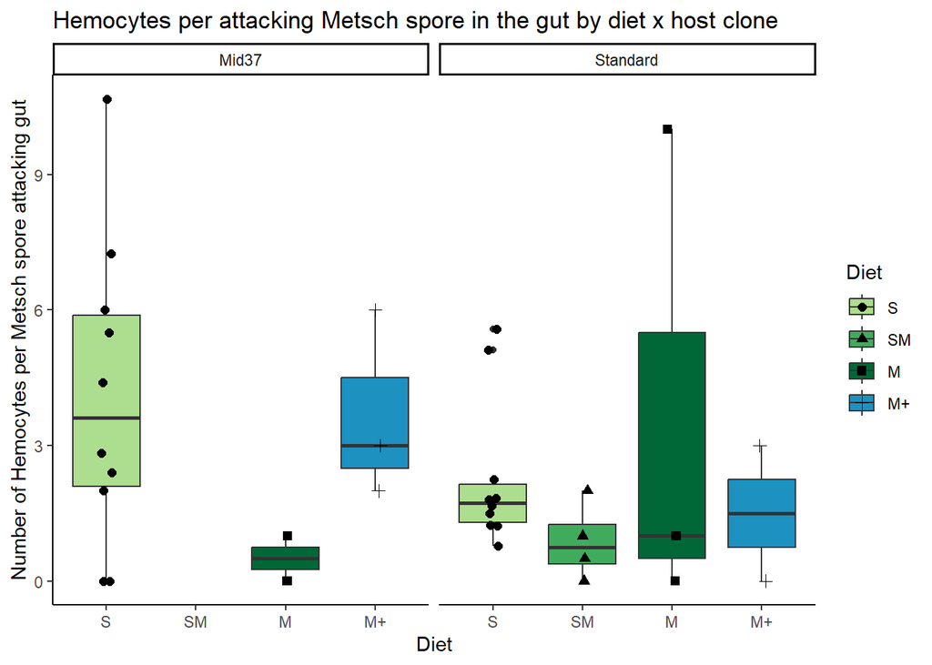

```r
m_hemocytesperspore_fig2 <- ggplot(m_data_hemocytes, aes(x = Diet, y = HemocytesPerSpore)) +
  geom_boxplot(aes(fill=Diet),position=position_dodge()) +
  geom_point(aes(shape=Diet), size=2, position=position_jitterdodge()) +
  facet_wrap(~Clone) +
  scale_fill_discrete(limits = c("S", "SM", "M", "M+")) +
  scale_shape_discrete(limits = c("S", "SM", "M", "M+")) +
  scale_fill_manual(values = diet_colors) +
  ggtitle("Hemocytes per attacking Metsch spore in the gut by diet x host clone") +
  labs(x = "Diet", y = "Number of Hemocytes per Metsch spore attacking gut") +
  theme_classic()
m_hemocytesperspore_fig2
```

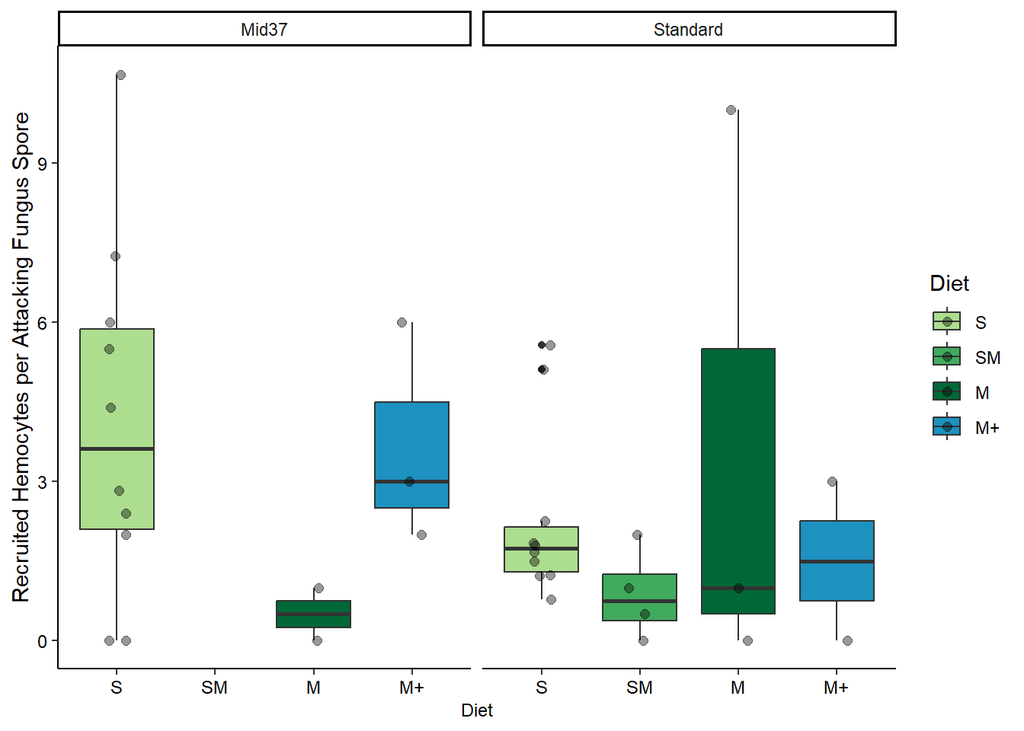

```r
# figure for presentation
m_hemocytesperspore_fig3 <- ggplot(m_data_hemocytes, aes(x = Diet, y = HemocytesPerSpore)) +
  geom_boxplot(aes(fill=Diet),position=position_dodge(width=0.7)) +
  geom_point(aes(color=Diet), size=2, position=position_jitterdodge(dodge.width=0.7, jitter.width = 0.7), alpha = 0.4) +
  facet_wrap(~Clone) +
  scale_fill_discrete(limits = c("S", "SM", "M", "M+")) +
  scale_fill_manual(values = diet_colors) +
  scale_color_manual(values = c(rep("black", 4))) +
  #ggtitle("Hemocytes per attacking Metsch spore in the gut by diet x host clone") +
  labs(x = "Diet", y = "Recruited Hemocytes per Attacking Fungus Spore") +
  theme_classic() +
  theme(axis.text = element_text(size=9, color = "black"), axis.title.y = element_text(size=11, color="black"),
        axis.title.x = element_text(size=9, color="black"))
m_hemocytesperspore_fig3
```

```r
ggsave("figures/HemocytesPerSpore_DietxClone.tiff", plot = m_hemocytesperspore_fig3, dpi = 600, width = 5, height = 4, units = "in", compression="lzw")
```

**Number of recruited hemoctyes model** This model is having some problems, so I don’t fully trust it yet…the GLM version is overdispered, so I added the unique code random effect to correct for the overdispersion. But when I do that, the model fails to converge if length is included. Even with length removed, it seems there is a bit of an issue because the figure can’t produce the confidence intervals…

In the GLMM with the random effect, there is only a significant positive correlation with the number of recruited hemoctyes. This matches what Tara previously found that the more attacking spores leads to more recruited hemoctyes.

In the GLM without the random effect there are significant interactions between Diet x Clone and Diet x length, and Total Punctured Spores attacking the gut has a significant positive correlation with the number of recruited hemoctyes. But this model is overdispersed, as discussed above, so may not be accurate.

**Recruited hemoctyes per spore model** There was no significant difference between diet or host clone in the number of recruited hemoctyes per attacking spore. Tested body legnth too, but it was not a significant predictor and the model AIC was improved by removing length from the model.

### Does number of attacking spores and/or number of recruited hemocytes predict terminal Metsch infection?

```r
m_data_inf <- m_data_gutspore %>% filter(!is.na(InfectionStatus))
dim(m_data_gutspore)
```

```
## [1] 77 38
```

```r
dim(m_data_inf)
```

```
## [1] 37 38
```

```r
mprevmod2 <- glm(InfectionStatus ~ Diet + Clone + TotalPunctSpores + Hemocytes, family = "binomial", data = m_data_inf)
summary(mprevmod2)
```

```
##
## Call:
## glm(formula = InfectionStatus ~ Diet + Clone + TotalPunctSpores +
##     Hemocytes, family = "binomial", data = m_data_inf)
##
## Deviance Residuals:
##      Min        1Q    Median        3Q       Max
## -1.17741  -0.00006  -0.00003   0.00000   1.79412
##
## Coefficients:
##                    Estimate Std. Error z value Pr(>|z|)
## (Intercept)         23.7287 79143.4598   0.000    1.000
## DietSM             -43.8902 78975.6251  -0.001    1.000
## DietM              -64.2790 79308.3075  -0.001    0.999
## DietM+             -45.2765 78975.6251  -0.001    1.000
## CloneStandard       20.1615  5620.9852   0.004    0.997
## TotalPunctSpores    -2.7666  8435.7351   0.000    1.000
## Hemocytes            0.3377  1549.6468   0.000    1.000
##
## (Dispersion parameter for binomial family taken to be 1)
##
##     Null deviance: 35.8933  on 36  degrees of freedom
## Residual deviance:  7.7766  on 30  degrees of freedom
## AIC: 21.777
##
## Number of Fisher Scoring iterations: 20
```

```r
Anova(mprevmod2)
```

```
## Analysis of Deviance Table (Type II tests)
##
## Response: InfectionStatus
##                  LR Chisq Df Pr(>Chisq)
## Diet               11.522  3   0.009212 **
## Clone               4.667  1   0.030747 *
## TotalPunctSpores    0.000  1   0.999961
## Hemocytes           0.000  1   0.999980
## ---
## Signif. codes:  0 '***' 0.001 '**' 0.01 '*' 0.05 '.' 0.1 ' ' 1
```

```r
overdisp_fun(mprevmod2)
```

```
##      chisq      ratio        rdf          p
##  7.0000000  0.2333333 30.0000000  0.9999957
```

```r
# Model does not perform well because there is too much separation in the data due to the effects of diet.
# if Diet and clone are removed, there is still no sig effects of Total punctured spores or # hemocytes on infection...

mprevmod_contrasts <- emmeans(mprevmod2, specs = pairwise ~ Diet | Clone, type = "response")
mprevmod_contrasts
```

```
## $emmeans
## Clone = Mid37:
##  Diet   prob   SE  df asymp.LCL asymp.UCL
##  S    1.0000    0 Inf  2.22e-16         1
##  SM   0.0000    0 Inf  2.22e-16         1
##  M    0.0000    0 Inf  2.22e-16         1
##  M+   0.0000    0 Inf  2.22e-16         1
##
## Clone = Standard:
##  Diet   prob   SE  df asymp.LCL asymp.UCL
##  S    1.0000    0 Inf  2.22e-16         1
##  SM   0.2320 2057 Inf  2.22e-16         1
##  M    0.0000    0 Inf  2.22e-16         1
##  M+   0.0702  754 Inf  2.22e-16         1
##
## Confidence level used: 0.95
## Intervals are back-transformed from the logit scale
##
## $contrasts
## Clone = Mid37:
##  contrast  odds.ratio       SE  df null z.ratio p.value
##  S / SM      1.15e+19 9.09e+23 Inf    1   0.001  1.0000
##  S / M       8.24e+27 6.54e+32 Inf    1   0.001  1.0000
##  S / (M+)    4.61e+19 3.64e+24 Inf    1   0.001  1.0000
##  SM / M      7.16e+08 5.19e+12 Inf    1   0.003  1.0000
##  SM / (M+)   4.00e+00 7.00e+00 Inf    1   0.769  0.8685
##  M / (M+)    0.00e+00 0.00e+00 Inf    1  -0.003  1.0000
##
## Clone = Standard:
##  contrast  odds.ratio       SE  df null z.ratio p.value
##  S / SM      1.15e+19 9.09e+23 Inf    1   0.001  1.0000
##  S / M       8.24e+27 6.54e+32 Inf    1   0.001  1.0000
##  S / (M+)    4.61e+19 3.64e+24 Inf    1   0.001  1.0000
##  SM / M      7.16e+08 5.19e+12 Inf    1   0.003  1.0000
##  SM / (M+)   4.00e+00 7.00e+00 Inf    1   0.769  0.8685
##  M / (M+)    0.00e+00 0.00e+00 Inf    1  -0.003  1.0000
##
## P value adjustment: tukey method for comparing a family of 4 estimates
## Tests are performed on the log odds ratio scale
```

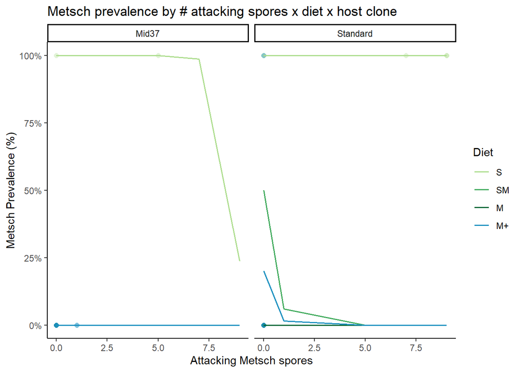

```r
# Marginal effects from best model with Abundance on the x axis
metsch_inf <- ggpredict(mprevmod2, c("TotalPunctSpores", "Diet", "Clone"))

# figure with Total punctured spores
m_inf_fig <- plot(metsch_inf, dodge = 0.4, add.data = T, ci = F) +
  scale_color_manual(values = diet_colors) +
  scale_fill_manual(values = diet_colors) +
  ggtitle("Metsch prevalence by # attacking spores x diet x host clone") +
  labs(x = "Attacking Metsch spores", y = "Metsch Prevalence (%)") +
  theme_classic()
m_inf_fig
```

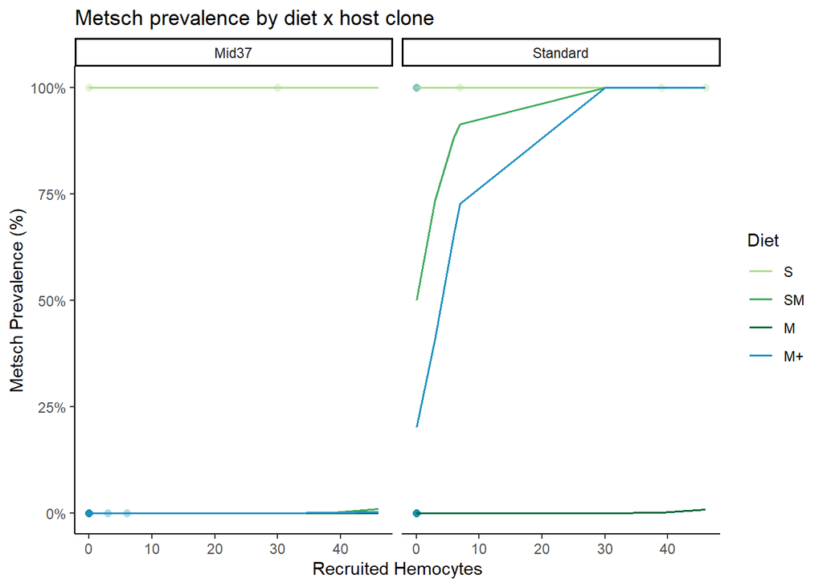

```r
# Marginal effects from best model with Abundance on the x axis
metsch_inf2 <- ggpredict(mprevmod2, c("Hemocytes", "Diet", "Clone"))

# figure with Total punctured spores
m_inf_fig2 <- plot(metsch_inf2, dodge = 0.4, add.data = T, ci = F) +
  scale_color_manual(values = diet_colors) +
  scale_fill_manual(values = diet_colors) +
  ggtitle("Metsch prevalence by diet x host clone") +
  labs(x = "Recruited Hemocytes", y = "Metsch Prevalence (%)") +
  theme_classic()
m_inf_fig2
```

I think the data here may be too sparse to be used well. Unfortunately many of the animals that I checked for spores in the guts died the day after I looked at them under the scope, so I was not able to assess terminal infection status for those animals. And there was an unfortunate trend that the more of the animals that had spores in their guts tended to die more either because I took longer to count them on the scope, and/or they were more sensitive since they were experiencing an infection.

## Fecundity

### Total Feculity by treatment for Pasteuria experiment

Compare differences in total fecundity in the Pasteuria experiment based on infection status, diet, and host clone.

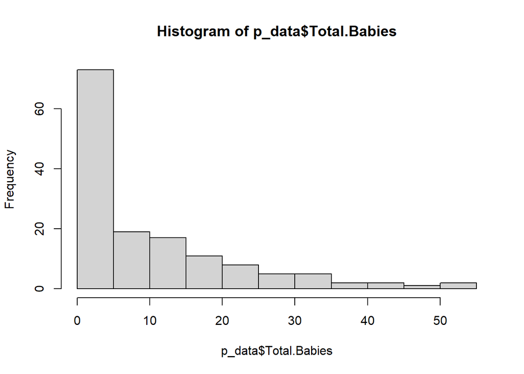

```r
p_data_fecund <- p_data %>% filter(!is.na(Total.Babies)  & lifespan.days > 11)
hist(p_data$Total.Babies)
```

```r
pfecundmod <- lmer(log(Total.Babies+1) ~ Diet * Infection * Clone + (1|Block), data = p_data_fecund)
```

```
## fixed-effect model matrix is rank deficient so dropping 2 columns / coefficients
```

```r
summary(pfecundmod)
```

```
## Linear mixed model fit by REML. t-tests use Satterthwaite's method [
## lmerModLmerTest]
## Formula: log(Total.Babies + 1) ~ Diet * Infection * Clone + (1 | Block)
##    Data: p_data_fecund
##
## REML criterion at convergence: 312
##
## Scaled residuals:
##      Min       1Q   Median       3Q      Max
## -2.77982 -0.46819 -0.01829  0.52191  2.38147
##
## Random effects:
##  Groups   Name        Variance Std.Dev.
##  Block    (Intercept) 0.00924  0.09612
##  Residual             0.61429  0.78377
## Number of obs: 139, groups:  Block, 2
##
## Fixed effects:
##                                          Estimate Std. Error         df t value
## (Intercept)                              2.862222   0.270007  42.739429  10.601
## DietSM                                  -0.409403   0.380903 116.074486  -1.075
## DietM                                   -1.831566   0.394986 116.003684  -4.637
## DietM+                                  -1.835409   0.360158 116.053607  -5.096
## InfectionExposed                        -0.731040   0.437810 116.586967  -1.670
## InfectionInfected                       -1.677069   0.438528 116.940440  -3.824
## CloneStandard                            0.095930   0.369630 116.195908   0.260
## DietSM:InfectionExposed                 -0.570288   0.649314 116.075806  -0.878
## DietM:InfectionExposed                   0.161494   0.597159 116.538412   0.270
## DietM+:InfectionExposed                 -0.189959   0.583594 116.190833  -0.325
## DietSM:InfectionInfected                -0.006485   0.625144 116.027981  -0.010
## DietM:InfectionInfected                  0.693966   0.948138 116.954485   0.732
## DietM+:InfectionInfected                 1.343403   0.748921 116.449572   1.794
## DietSM:CloneStandard                     0.407507   0.538763 116.146111   0.756
## DietM:CloneStandard                      0.544741   0.540854 116.001966   1.007
## DietM+:CloneStandard                     0.796216   0.516194 116.224166   1.542
## InfectionExposed:CloneStandard           0.865453   0.580079 116.227758   1.492
## InfectionInfected:CloneStandard          0.868589   0.934739 116.020543   0.929
## DietSM:InfectionExposed:CloneStandard    0.563369   0.843873 116.182611   0.668
## DietM:InfectionExposed:CloneStandard    -0.272652   0.811249 116.453874  -0.336
## DietM+:InfectionExposed:CloneStandard   -0.463503   0.800846 116.000323  -0.579
```

[output cut: 11 more lines]

```
## DietM+:InfectionExposed                0.745389
## DietSM:InfectionInfected               0.991741
## DietM:InfectionInfected                0.465679
## DietM+:InfectionInfected               0.075443 .
## DietSM:CloneStandard                   0.450956
## DietM:CloneStandard                    0.315942
## DietM+:CloneStandard                   0.125677
## InfectionExposed:CloneStandard         0.138420
## InfectionInfected:CloneStandard        0.354699
## DietSM:InfectionExposed:CloneStandard  0.505714
## DietM:InfectionExposed:CloneStandard   0.737408
## DietM+:InfectionExposed:CloneStandard  0.563868
## DietM+:InfectionInfected:CloneStandard 0.195252
## ---
## Signif. codes:  0 '***' 0.001 '**' 0.01 '*' 0.05 '.' 0.1 ' ' 1
```

```
##
## Correlation matrix not shown by default, as p = 22 > 12.
## Use print(x, correlation=TRUE)  or
##     vcov(x)        if you need it
```

```
## fit warnings:
## fixed-effect model matrix is rank deficient so dropping 2 columns / coefficients
```

```r
Anova(pfecundmod)
```

```
## Analysis of Deviance Table (Type II Wald chisquare tests)
##
## Response: log(Total.Babies + 1)
##                         Chisq Df Pr(>Chisq)
## Diet                 104.3771  3  < 2.2e-16 ***
## Infection             28.2177  2  7.458e-07 ***
## Clone                 38.2923  1  6.090e-10 ***
## Diet:Infection         4.4622  6     0.6144
## Diet:Clone             2.3176  3     0.5092
## Infection:Clone        7.7071  2     0.0212 *
## Diet:Infection:Clone   3.1488  4     0.5332
## ---
## Signif. codes:  0 '***' 0.001 '**' 0.01 '*' 0.05 '.' 0.1 ' ' 1
```

```r
overdisp_fun(pfecundmod)
```

```
##       chisq       ratio         rdf           p
##  71.5717861   0.6223634 115.0000000   0.9994944
```

```r
pfecundmod_contrasts <- emmeans(pfecundmod, specs = pairwise ~ Diet + Infection | Clone, type = "response")
pfecundmod_contrasts
```

```
## $emmeans
## Clone = Mid37:
##  Diet Infection  response    SE    df lower.CL upper.CL
##  S    Uninfected  16.5004 4.729  42.7   9.1467    29.18
##  SM   Uninfected  10.6211 3.331  48.7   5.5316    19.68
##  M    Uninfected   1.8029 0.853  57.2   0.5239     4.16
##  M+   Uninfected   1.7922 0.718  37.4   0.6591     3.70
##  S    Exposed      7.4248 3.060  72.7   3.0849    16.38
##  SM   Exposed      2.1629 1.270  86.4   0.4237     6.03
##  M    Exposed      0.5858 0.452  49.5  -0.1060     1.81
##  M+   Exposed      0.1116 0.338  57.2  -0.3956     1.04
##  S    Infected     2.2712 1.188  72.7   0.5861     5.75
##  SM   Infected     1.1582 0.784  72.7   0.0464     3.45
##  M    Infected     0.0487 0.833 115.5  -0.7826     4.06
##  M+   Infected     1.0000 1.117 110.8  -0.3385     5.05
##
## Clone = Standard:
##  Diet Infection  response    SE    df lower.CL upper.CL
##  S    Uninfected  18.2623 5.205  42.7  10.1683    32.22
##  SM   Uninfected  18.2258 5.511  48.7   9.8059    33.21
##  M    Uninfected   4.3192 1.437  42.7   2.0841     8.17
##  M+   Uninfected   5.8139 1.841  42.7   2.9507    10.75
##  S    Exposed     21.0335 6.287  49.5  11.4206    38.09
##  SM   Exposed     20.8401 5.902  42.7  11.6629    36.67
##  M    Exposed      4.4444 1.657  57.2   1.9600     9.01
##  M+   Exposed      3.0548 1.234  57.2   1.2045     6.46
##  S    Infected     7.5820 6.818 115.5   0.7790    40.40
##  SM   Infected     nonEst    NA    NA       NA       NA
##  M    Infected     nonEst    NA    NA       NA       NA
##  M+   Infected     0.9071 1.515 115.5  -0.6047     8.20
##
## Degrees-of-freedom method: kenward-roger
## Confidence level used: 0.95
## Intervals are back-transformed from the log(mu + 1) scale
##
## $contrasts
## Clone = Mid37:
##  contrast                         ratio      SE  df null t.ratio p.value
##  S Uninfected / SM Uninfected     1.506  0.5740 116    1   1.074  0.9952
##  S Uninfected / M Uninfected      6.244  2.4662 116    1   4.637  0.0006
```

[output cut: 122 more lines]

```
##  M Exposed / (M+ Infected)        2.855  2.4191 117    1   1.238  0.9847
##  (M+ Exposed) / S Infected        0.472  0.3984 117    1  -0.889  0.9991
##  (M+ Exposed) / SM Infected      nonEst      NA  NA    1      NA      NA
##  (M+ Exposed) / M Infected       nonEst      NA  NA    1      NA      NA
##  (M+ Exposed) / (M+ Infected)     2.126  1.7929 117    1   0.895  0.9991
##  S Infected / SM Infected        nonEst      NA  NA    1      NA      NA
##  S Infected / M Infected         nonEst      NA  NA    1      NA      NA
##  S Infected / (M+ Infected)       4.500  4.9879 116    1   1.357  0.9692
##  SM Infected / M Infected        nonEst      NA  NA    1      NA      NA
##  SM Infected / (M+ Infected)     nonEst      NA  NA    1      NA      NA
##  M Infected / (M+ Infected)      nonEst      NA  NA    1      NA      NA
##
## Degrees-of-freedom method: kenward-roger
## P value adjustment: tukey method for comparing a family of 12 estimates
## Tests are performed on the log scale
```

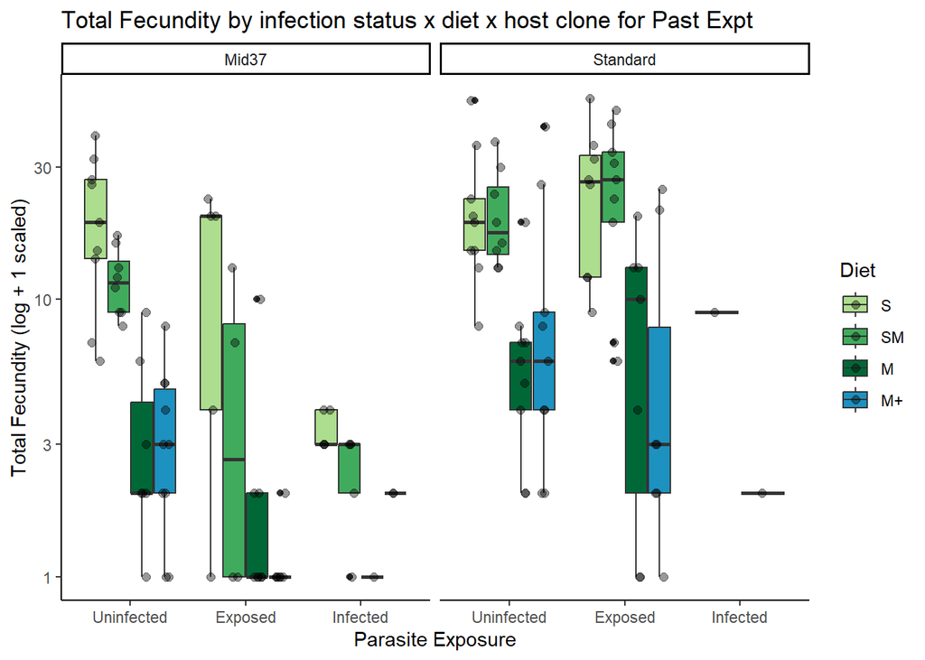

```r
p_fecund_tot <- ggplot(p_data_fecund, aes(x = Infection, y = Total.Babies+1)) +
  geom_boxplot(aes(fill=Diet),position=position_dodge(width=0.8)) +
  geom_point(aes(color=Diet), size=2, position=position_jitterdodge(dodge.width=0.8, jitter.width = 0.25), alpha = 0.4) +
  facet_wrap(~Clone) +
  scale_x_discrete(limits = c("Uninfected", "Exposed", "Infected")) +
  scale_fill_discrete(limits = c("S", "SM", "M", "M+")) +
  scale_fill_manual(values = diet_colors) +
  scale_color_manual(values = c(rep("black", 4))) +
  scale_y_log10(labels = scales::comma) +
  ggtitle("Total Fecundity by infection status x diet x host clone for Past Expt") +
  labs(x = "Parasite Exposure", y = "Total Fecundity (log + 1 scaled)") +
  theme_classic()
p_fecund_tot
```

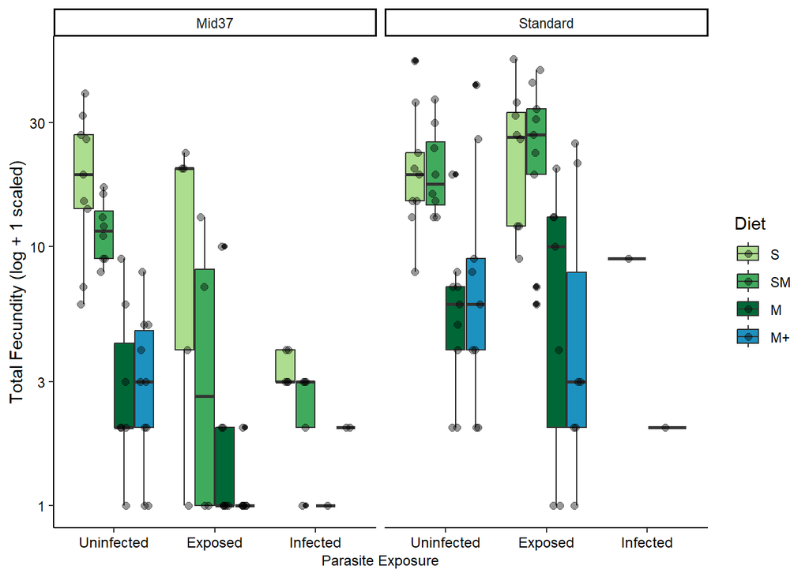

```r
# figure for presentation
p_fecund_tot2 <- ggplot(p_data_fecund, aes(x = Infection, y = Total.Babies+1)) +
  geom_boxplot(aes(fill=Diet),position=position_dodge(width=0.8)) +
  geom_point(aes(color=Diet), size=2, position=position_jitterdodge(dodge.width=0.8, jitter.width = 0.25), alpha = 0.4) +
  facet_wrap(~Clone) +
  scale_x_discrete(limits = c("Uninfected", "Exposed", "Infected")) +
  scale_fill_discrete(limits = c("S", "SM", "M", "M+")) +
  scale_fill_manual(values = diet_colors) +
  scale_color_manual(values = c(rep("black", 4))) +
  scale_y_log10(labels = scales::comma) +
  #ggtitle("Total Fecundity by infection status x diet x host clone for Past Expt") +
  labs(x = "Parasite Exposure", y = "Total Fecundity (log + 1 scaled)") +
  theme_classic() +
  theme(axis.text = element_text(size=9, color = "black"), axis.title.y = element_text(size=11, color="black"),
        axis.title.x = element_text(size=9, color="black"))
p_fecund_tot2
```

```r
ggsave("figures/PastTotalFecundity_DietxClonexInfection.tiff", plot = p_fecund_tot2, dpi = 600, width = 6.5, height = 4, units = "in", compression="lzw")
```

Generally, decreasing resource quality leads to lower total fecundity. Pasteuria infected animals have fewer babies due to the parasite castration, though interestingly in the high quality diet some animals are able to have their first clutch before infection castrates them. And overall, Standards typically had more babies than Mid37s (though I think at a cost to their long-term survival…we will see below.)

I am not sure why the poisson distribution did not work…I thought that the poisson distribution should automatically log the response variable within the model to deal with count data…

**Question:** What is the best way to account for Clone differences in the models? Do we care whether there are sig differences there? If not, then it may be better/easier to separate the data based on clone?

### Total Feculity by treatment for Metsch experiment

Compare differences in total fecundity in the Metsch experiment based on infection status, diet, and host clone.

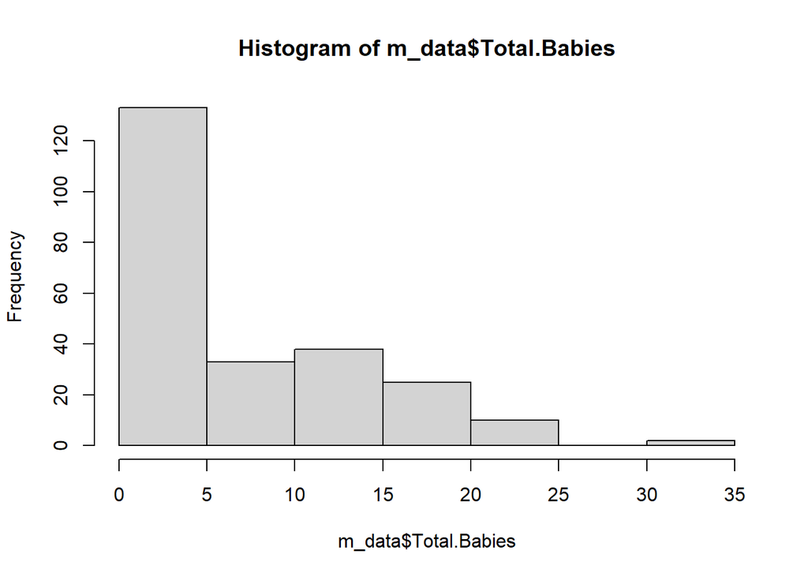

```r
m_data_fecund <- m_data %>% filter(!is.na(Total.Babies) & lifespan.days > 11)
hist(m_data$Total.Babies)
```

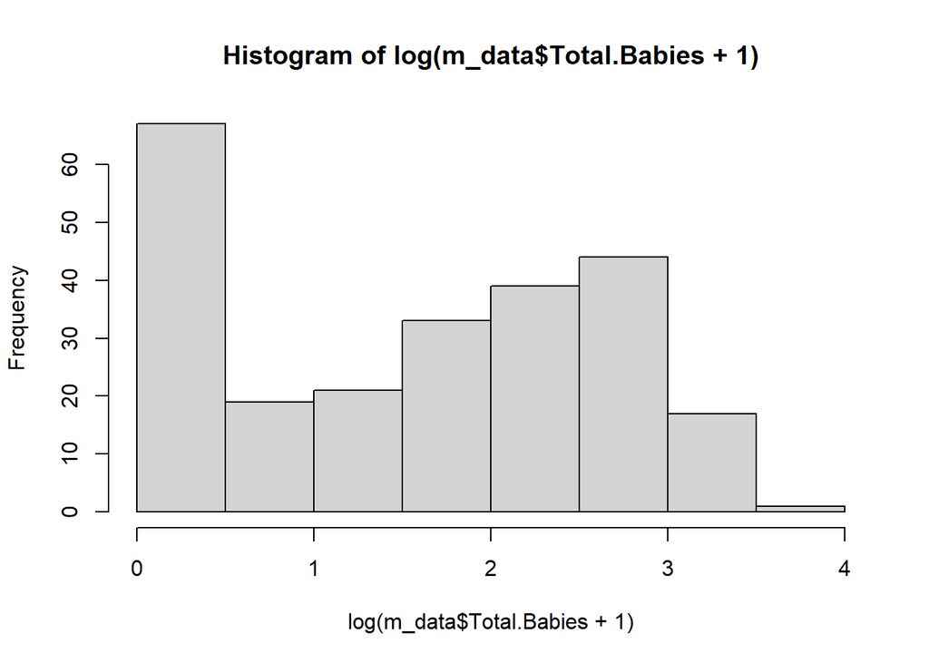

```r
hist(log(m_data$Total.Babies+1))
```

```r
mfecundmod <- lmer(log(Total.Babies+1) ~ Diet * Infection * Clone + (1|Block), data = m_data_fecund)
```

```
## fixed-effect model matrix is rank deficient so dropping 4 columns / coefficients
```

```r
summary(mfecundmod)
```

```
## Linear mixed model fit by REML. t-tests use Satterthwaite's method [
## lmerModLmerTest]
## Formula: log(Total.Babies + 1) ~ Diet * Infection * Clone + (1 | Block)
##    Data: m_data_fecund
##
## REML criterion at convergence: 353.3
##
## Scaled residuals:
##     Min      1Q  Median      3Q     Max
## -3.6292 -0.3425  0.1303  0.6454  1.6849
##
## Random effects:
##  Groups   Name        Variance Std.Dev.
##  Block    (Intercept) 0.05569  0.2360
##  Residual             0.38116  0.6174
## Number of obs: 185, groups:  Block, 3
##
## Fixed effects:
##                                         Estimate Std. Error        df t value
## (Intercept)                              2.74510    0.24101  13.47359  11.390
## DietSM                                  -1.09939    0.28372 162.88956  -3.875
## DietM                                   -1.45704    0.28372 162.88956  -5.135
## DietM+                                  -1.41765    0.27610 162.87537  -5.135
## InfectionExposed                        -0.88645    0.40814 163.35314  -2.172
## InfectionInfected                       -0.90386    0.28486 163.34640  -3.173
## CloneStandard                            0.39449    0.29285 162.87537   1.347
## DietSM:InfectionExposed                  0.57233    0.48952 162.94094   1.169
## DietM:InfectionExposed                   0.76318    0.48286 162.93408   1.581
## DietM+:InfectionExposed                  0.65712    0.47398 162.92604   1.386
## DietSM:InfectionInfected                -0.65661    0.71317 163.24431  -0.921
## DietM+:InfectionInfected                -0.65827    0.71008 163.48635  -0.927
## DietSM:CloneStandard                     1.08973    0.40360 162.91614   2.700
## DietM:CloneStandard                      1.06662    0.40360 162.91614   2.643
## DietM+:CloneStandard                     1.05866    0.40266 162.92311   2.629
## InfectionExposed:CloneStandard          -0.56179    0.34870 163.05240  -1.611
## InfectionInfected:CloneStandard          0.13987    0.39997 162.89836   0.350
## DietSM:InfectionExposed:CloneStandard    0.49631    0.52252 163.02257   0.950
## DietM:InfectionExposed:CloneStandard     0.03066    0.51622 162.97946   0.059
## DietSM:InfectionInfected:CloneStandard   0.37965    0.90130 163.10723   0.421
##                                        Pr(>|t|)
## (Intercept)                            2.71e-08 ***
## DietSM                                 0.000154 ***
## DietM                                  7.95e-07 ***
## DietM+                                 7.99e-07 ***
## InfectionExposed                       0.031302 *
## InfectionInfected                      0.001803 **
## CloneStandard                          0.179826
## DietSM:InfectionExposed                0.244039
## DietM:InfectionExposed                 0.115925
## DietM+:InfectionExposed                0.167523
## DietSM:InfectionInfected               0.358573
## DietM+:InfectionInfected               0.355271
## DietSM:CloneStandard                   0.007665 **
## DietM:CloneStandard                    0.009025 **
## DietM+:CloneStandard                   0.009379 **
## InfectionExposed:CloneStandard         0.109097
## InfectionInfected:CloneStandard        0.727016
## DietSM:InfectionExposed:CloneStandard  0.343599
## DietM:InfectionExposed:CloneStandard   0.952706
## DietSM:InfectionInfected:CloneStandard 0.674146
## ---
## Signif. codes:  0 '***' 0.001 '**' 0.01 '*' 0.05 '.' 0.1 ' ' 1
```

```
##
## Correlation matrix not shown by default, as p = 20 > 12.
## Use print(x, correlation=TRUE)  or
##     vcov(x)        if you need it
```

```
## fit warnings:
## fixed-effect model matrix is rank deficient so dropping 4 columns / coefficients
```

```r
Anova(mfecundmod)
```

```
## Analysis of Deviance Table (Type II Wald chisquare tests)
##
## Response: log(Total.Babies + 1)
##                         Chisq Df Pr(>Chisq)
## Diet                  45.5191  3  7.177e-10 ***
## Infection             36.9859  2  9.303e-09 ***
## Clone                134.5244  1  < 2.2e-16 ***
## Diet:Infection         4.9397  5   0.423282
## Diet:Clone            15.1375  3   0.001703 **
## Infection:Clone        4.0477  2   0.132148
## Diet:Infection:Clone   1.1273  3   0.770481
## ---
## Signif. codes:  0 '***' 0.001 '**' 0.01 '*' 0.05 '.' 0.1 ' ' 1
```

```r
mfecundmod_contrasts <- emmeans(mfecundmod, specs = pairwise ~ Diet + Infection | Clone, type = "response")
mfecundmod_contrasts
```

```
## $emmeans
## Clone = Mid37:
##  Diet Infection  response    SE     df lower.CL upper.CL
##  S    Uninfected   14.566 3.767  14.27    8.272    25.13
##  SM   Uninfected    4.185 1.299  16.29    2.050     7.81
##  M    Uninfected    2.626 0.909  16.29    1.133     5.16
##  M+   Uninfected    2.771 0.913  14.27    1.246     5.33
##  S    Exposed       5.415 2.448  66.65    1.995    12.74
##  SM   Exposed       2.787 0.855  11.26    1.307     5.22
##  M    Exposed       2.205 0.675   8.62    0.984     4.18
##  M+   Exposed       1.999 0.600   7.06    0.870     3.81
##  S    Infected      5.304 1.559  15.99    2.732     9.65
##  SM   Infected      0.089 0.693 144.15   -0.690     2.83
##  M    Infected     nonEst    NA     NA       NA       NA
##  M+   Infected     nonEst    NA     NA       NA       NA
##
## Clone = Standard:
##  Diet Infection  response    SE     df lower.CL upper.CL
##  S    Uninfected   22.094 6.026  18.94   12.374    38.88
##  SM   Uninfected   21.872 5.325  12.53   12.805    36.90
##  M    Uninfected   14.630 3.639  12.53    8.433    24.90
##  M+   Uninfected   15.129 3.873  14.10    8.640    25.98
##  S    Exposed      nonEst    NA     NA       NA       NA
##  SM   Exposed      14.648 3.891  16.13    8.239    25.50
##  M    Exposed       7.124 2.022  16.14    3.794    12.76
##  M+   Exposed       6.312 1.506   7.96    3.546    10.76
##  S    Infected      9.757 2.417  11.12    5.565    16.63
##  SM   Infected      7.077 3.704  99.35    2.251    19.06
##  M    Infected     nonEst    NA     NA       NA       NA
##  M+   Infected      2.890 2.482 143.47    0.102    12.73
##
## Degrees-of-freedom method: kenward-roger
## Confidence level used: 0.95
## Intervals are back-transformed from the log(mu + 1) scale
##
## $contrasts
## Clone = Mid37:
##  contrast                         ratio    SE  df null t.ratio p.value
##  S Uninfected / SM Uninfected     3.002 0.852 163    1   3.875  0.0083
##  S Uninfected / M Uninfected      4.293 1.218 163    1   5.135  0.0001
```

[output cut: 122 more lines]

```
##  M Exposed / (M+ Infected)        2.088 1.365 163    1   1.127  0.9930
##  (M+ Exposed) / S Infected        0.680 0.161 163    1  -1.633  0.8942
##  (M+ Exposed) / SM Infected       0.905 0.420 163    1  -0.214  1.0000
##  (M+ Exposed) / M Infected       nonEst    NA  NA    1      NA      NA
##  (M+ Exposed) / (M+ Infected)     1.880 1.206 164    1   0.984  0.9979
##  S Infected / SM Infected         1.332 0.630 163    1   0.606  1.0000
##  S Infected / M Infected         nonEst    NA  NA    1      NA      NA
##  S Infected / (M+ Infected)       2.766 1.798 164    1   1.565  0.9190
##  SM Infected / M Infected        nonEst    NA  NA    1      NA      NA
##  SM Infected / (M+ Infected)      2.076 1.577 163    1   0.962  0.9983
##  M Infected / (M+ Infected)      nonEst    NA  NA    1      NA      NA
##
## Degrees-of-freedom method: kenward-roger
## P value adjustment: tukey method for comparing a family of 12 estimates
## Tests are performed on the log scale
```

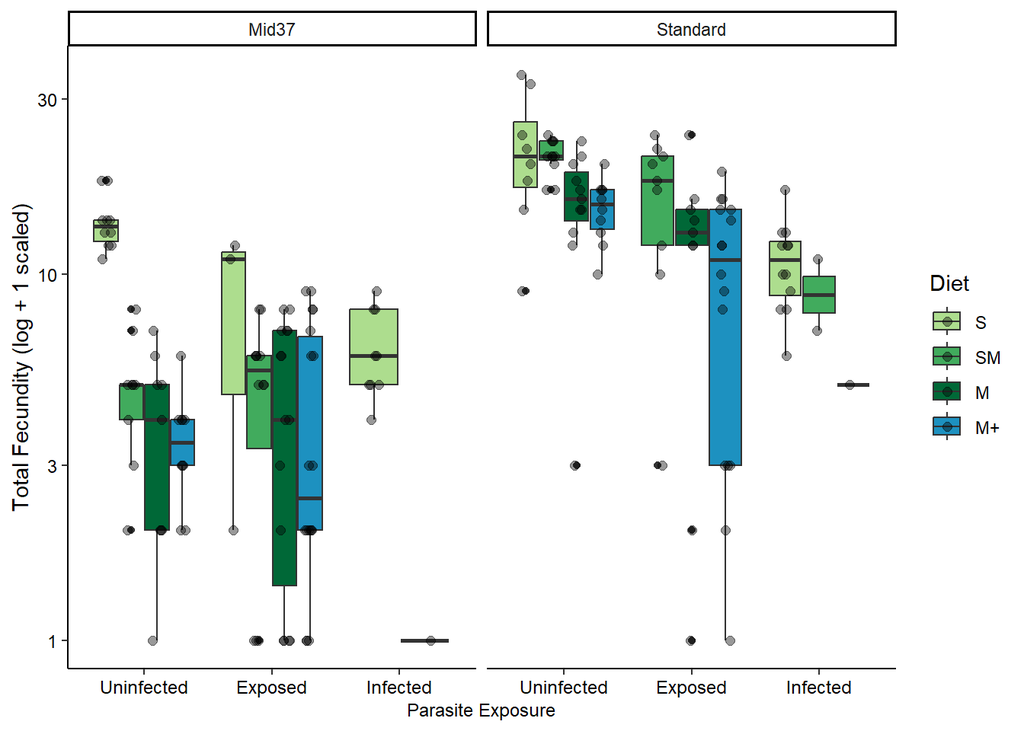

```r
m_fecund_tot2 <- ggplot(m_data_fecund, aes(x = Infection, y = Total.Babies+1)) +
  geom_boxplot(aes(fill=Diet),position=position_dodge(width =0.8)) +
  geom_point(aes(color=Diet), size=2, position=position_jitterdodge(dodge.width=0.8, jitter.width = 0.25), alpha = 0.4) +
  facet_wrap(~Clone) +
  scale_x_discrete(limits = c("Uninfected", "Exposed", "Infected")) +
  scale_fill_discrete(limits = c("S", "SM", "M", "M+")) +
  scale_fill_manual(values = diet_colors) +
  scale_color_manual(values = c(rep("black", 4))) +
  scale_y_log10(labels = scales::comma) +
  #ggtitle("Total Fecundity by infection status x diet x host clone for Metsch Expt") +
  labs(x = "Parasite Exposure", y = "Total Fecundity (log + 1 scaled)") +
  theme_classic() +
  theme(axis.text = element_text(size=9, color = "black"), axis.title.y = element_text(size=11, color="black"),
        axis.title.x = element_text(size=9, color="black"))
m_fecund_tot2
```

```r
ggsave("figures/MetschTotalFecundity_DietxClonexInfection.tiff", plot = m_fecund_tot2, dpi = 600, width = 6.5, height = 4, units = "in", compression="lzw")
```

**Question 1:** There are some differences in the sample size since we are doing it based off of the infection status (i.e. some treatments with very few infected or very few exposed depending on the prevalence in that treatment). Is there a better way to account for this? You can see where there are only a few points in the boxplots…

**Question 2:** Is the best way to visualize these difference by using letters on top of the different boxplots? Or adding the sig interaction effects in an annotation?

### Cummulative Fecunity over time

Need to do this still…

**Should this be average cumulative fecundity over time by treatment? Not sure how to best make this plot**

```r
#fecund_time <- ggplot()

#fecund_time
```

### Little r by treatment for Pasteuria experiment

**Question:** Should I use r_mx or r_Fx? They are similar but slightly different versions. I have used r_mx for now but can easily change it.

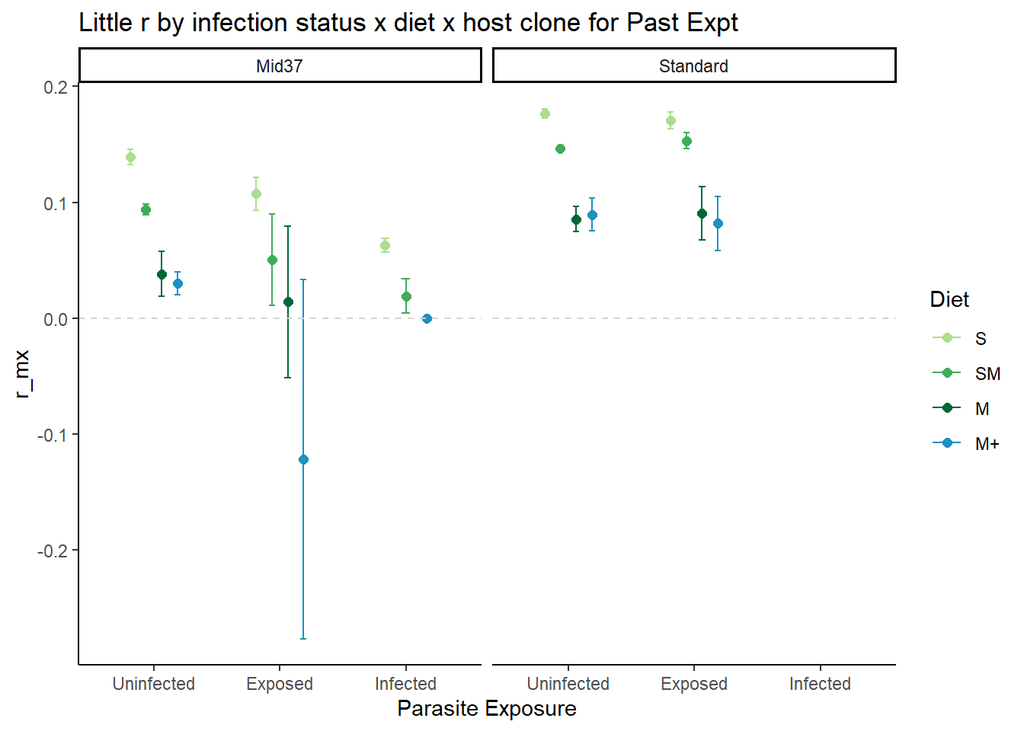

```r
p_little_r <- ggplot(p_lifetable, aes(x = Infection, y = r_mx)) +
  geom_point(aes(color=Diet), size=2, position=position_dodge(width=0.5)) +
  geom_errorbar(aes(ymin = r_mx-Std.error_r_mx, ymax=r_mx+Std.error_r_mx, color=Diet), width = 0.2,  position=position_dodge(width=0.5)) +
  geom_hline(yintercept = 0, linetype = "dashed", color = "lightgray") +
  facet_wrap(~Clone) +
  scale_x_discrete(limits = c("Uninfected", "Exposed", "Infected")) +
  scale_color_discrete(limits = c("S", "SM", "M", "M+")) +
  scale_color_manual(values = diet_colors) +
  ggtitle("Little r by infection status x diet x host clone for Past Expt") +
  labs(x = "Parasite Exposure", y = "r_mx") +
  theme_classic()
p_little_r
```

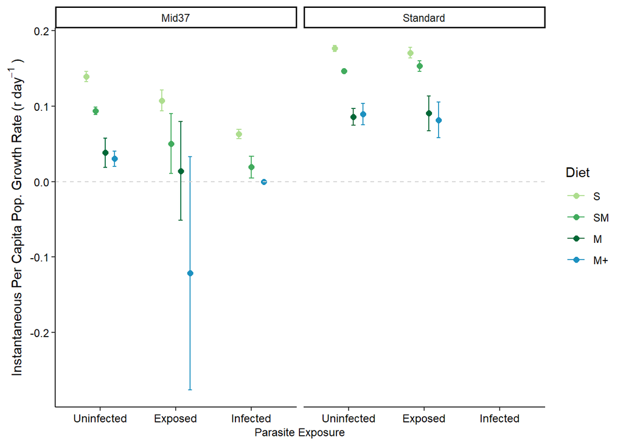

```r
# figure for presentation
p_little_r2 <- ggplot(p_lifetable, aes(x = Infection, y = r_mx)) +
  geom_point(aes(color=Diet), size=2, position=position_dodge(width=0.5)) +
  geom_errorbar(aes(ymin = r_mx-Std.error_r_mx, ymax=r_mx+Std.error_r_mx, color=Diet), width = 0.2,  position=position_dodge(width=0.5)) +
  geom_hline(yintercept = 0, linetype = "dashed", color = "lightgray") +
  facet_wrap(~Clone) +
  scale_x_discrete(limits = c("Uninfected", "Exposed", "Infected")) +
  scale_color_discrete(limits = c("S", "SM", "M", "M+")) +
  scale_color_manual(values = diet_colors) +
  #ggtitle("Little r by infection status x diet x host clone for Past Expt") +
  labs(x = "Parasite Exposure", y = bquote("Instantaneous Per Capita Pop. Growth Rate (r"~day^-1~")")) +
  theme_classic() +
  theme(axis.text = element_text(size=9, color = "black"), axis.title.y = element_text(size=11, color="black"),
        axis.title.x = element_text(size=9, color="black"))
p_little_r2
```

```r
ggsave("figures/PastLittleR_DietxClonexInfection.tiff", plot = p_little_r2, dpi = 600, width = 6.5, height = 4, units = "in", compression="lzw")
```

High quality diets produce the largest little r instanteous growth rates, and decreases with poorer quality diet. Exposure to Pasteuria, but not getting infected seems to reduce the little r for Mid37s a bit, but not for standards. Infection with Pasteuria results in castration, so those animals have very low little r’s. Overall, there is not much of a difference in little r for M vs spiked toxin M treatments, except for exposed Mid37s, which have a very low little r with a wide standard error. This effect is not seen for Standards.

### Little r by treatment for Metsch experiment

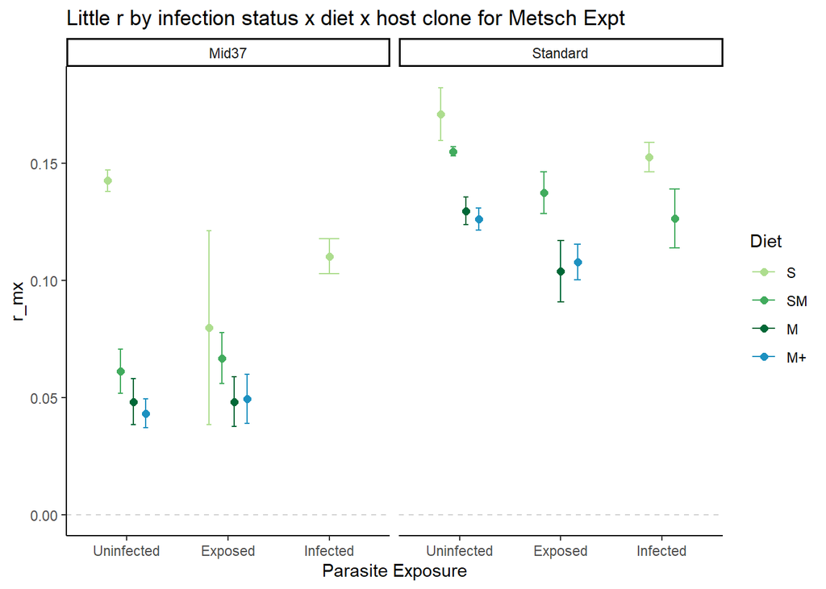

```r
m_little_r <- ggplot(m_lifetable, aes(x = Infection, y = r_mx)) +
  geom_point(aes(color=Diet), size=2, position=position_dodge(width=0.5)) +
  geom_errorbar(aes(ymin = r_mx-Std.error_r_mx, ymax=r_mx+Std.error_r_mx, color=Diet), width = 0.2,  position=position_dodge(width=0.5)) +
  geom_hline(yintercept = 0, linetype = "dashed", color = "lightgray") +
  facet_wrap(~Clone) +
  scale_x_discrete(limits = c("Uninfected", "Exposed", "Infected")) +
  scale_color_discrete(limits = c("S", "SM", "M", "M+")) +
  scale_color_manual(values = diet_colors) +
  ggtitle("Little r by infection status x diet x host clone for Metsch Expt") +
  labs(x = "Parasite Exposure", y = "r_mx") +
  theme_classic()
m_little_r
```

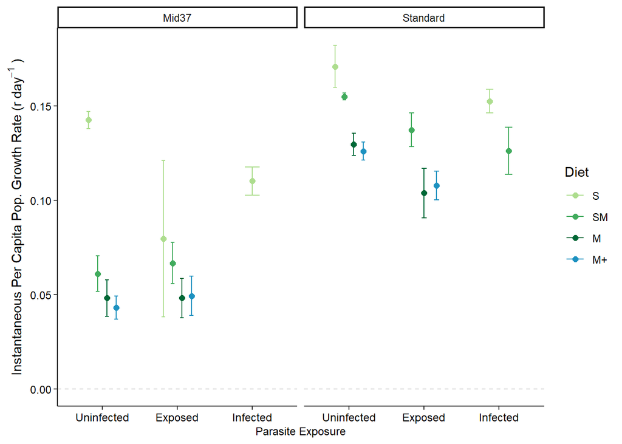

```r
# figure for presentation
m_little_r2 <- ggplot(m_lifetable, aes(x = Infection, y = r_mx)) +
  geom_point(aes(color=Diet), size=2, position=position_dodge(width=0.5)) +
  geom_errorbar(aes(ymin = r_mx-Std.error_r_mx, ymax=r_mx+Std.error_r_mx, color=Diet), width = 0.2,  position=position_dodge(width=0.5)) +
  geom_hline(yintercept = 0, linetype = "dashed", color = "lightgray") +
  facet_wrap(~Clone) +
  scale_x_discrete(limits = c("Uninfected", "Exposed", "Infected")) +
  scale_color_discrete(limits = c("S", "SM", "M", "M+")) +
  scale_color_manual(values = diet_colors) +
  #ggtitle("Little r by infection status x diet x host clone for Metsch Expt") +
  labs(x = "Parasite Exposure", y = bquote("Instantaneous Per Capita Pop. Growth Rate (r"~day^-1~")")) +
  theme_classic() +
  theme(axis.text = element_text(size=9, color = "black"), axis.title.y = element_text(size=11, color="black"),
        axis.title.x = element_text(size=9, color="black"))
m_little_r2
```

```r
ggsave("figures/MetschLittleR_DietxClonexInfection.tiff", plot = m_little_r2, dpi = 600, width = 6.5, height = 4, units = "in", compression="lzw")
```

Metsch does not castrate it’s host, so there is less of a dramatic effect on little r based on parasite infection. As diet quality decreases, little r decreases as well for both host clones and regardless of infection. In Standards, little r seems to be lower in animals exposed or infected with Metsch compared to uninfected animals, so maybe there is an energetic cost to resisting infection, and getting infected would definitely be costly for the animal. There doesn’t seem to be this same difference in MId37s, except for in the high quality S diet treatment. Again there are no major differences between the Microcystis and toxin spiked Microcystis treatments.

Note that since the Metsch experiment was ended after 16 days post-exposure, the differences between the infected animals that died before the end of the experiment and the uninfected/exposed animals that were still alive at the end of the experiment would have become greater.